# Part 4

## Setting up a convex problem

We first consider the 2D case as this allows for pretty visuals. We then move over to a bigger problem.

A general equation of a paraboloid is stated with three terms: $$P(x) = x^{T}Ax + Cx + d $$ for $A \in \mathbb{R}^{n\times{n}} \succ{0}$, $C\in\mathbb{R}^{n}$, and $d\in\mathbb{R}$

Using this rule, we generate data:

#### For projected gradient descent, the problem may be formulated as follows:

$$ \min_{x\in K} P(x) \text{ s.t. } ||{x}||\leq{R} $$

where $K$ is a convex set. The gradient writes as $$\nabla{P} = 2Ax + C$$

For this project we consider 3 different convex sets.

- If $K$ is the $\ell_2$-ball, the projection may be expressed as: $$\Pi_{A}(x) = \frac{R}{max(||x||_2, R)}x$$
- Projection onto the simplex with sum R
- Projection onto the $\ell_1$-ball with radius R

The last 2 projections have algorithms proposed by Laurent Condat in his paper *Fast Projection onto the Simplex and the l1 Ball*

*(See Laurent Condat. Fast Projection onto the Simplex and the l1 Ball. Mathematical Programming, Series A, 2016, 158 (1), pp.575-585. 10.1007/s10107-015-0946-6. hal-01056171v2)*

#### For the Franke-Wolfe / Conditional gradient

When the convex set $K$ is the $\ell_2$-ball with radius R, we wish to solve:

\begin{equation}\tag{1} s_{k+1} \in \underset{s \in B(0,R)}{\mathrm{argmin}} \big\{ f(x_k) + \langle\ \nabla f(x_k), s - x_k \rangle\ \big\} \end{equation}

which is known to have explicit solution: \begin{equation}\tag{2} s_{k+1,j} = - R \frac{\text{sign}(\nabla f_j(x_k))|\nabla f_j(x_k)|}{||\nabla f(x_k)||_2} \end{equation} The weighting of the convex combination may be determined by exact linesearch: \begin{equation}\tag{3} \theta_k \in \text{argmin}_{\theta\in{[0,1]}} f(\theta_k s_{k+1} + (1-\theta) x_k) \end{equation}

or by making use of a prescribed step size such as \begin{equation}\tag{4} \theta_k = \frac{2}{k+2} \end{equation}

We choose an arbitrary starting point $x_0$ on the boundary of the two balls with radius $R$ and run an iteration of PGD for each:

We plot the successive differences between iterates on normal and log scale

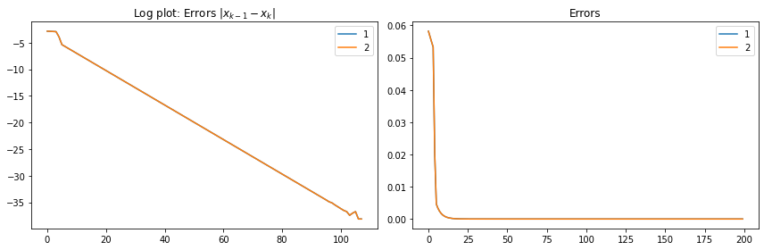

For a problem of small dimension as here, we may determine the exact solution by making use of scipy's *optimize* library. The optimal solution $x^*$ is:

```
array([-0.17323659, -1.24429379])
```

We plot the true values of the iterates as black lines and for each of the $\ell_1$, $\ell_2$ balls, plot the evolution of the iterates.

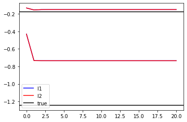

As we first consider a 2D small problem, we may plot the evolution of the iterates in the $\ell_2$ ball in 3D space

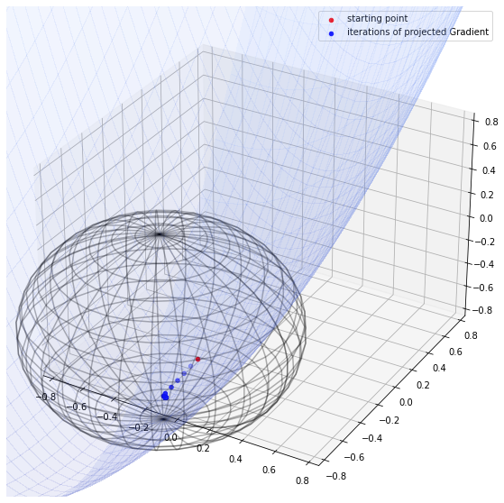

We now compare the two methods on two different balls.

### For the $\ell_1$-ball

[figure not shown]

Both iterates converge fairly quickly when considering successive differences in the norm:

```
Final Difference:
Cond: 0.002388635446043774
Proj: 0.006459105890068564
```

We note, however, that CGD converges faster for this ball

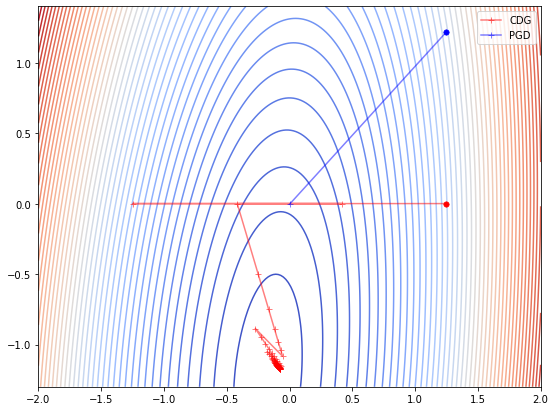

### For the $\ell_2$-ball

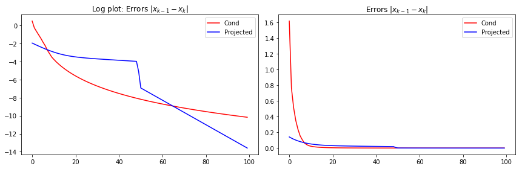

```
Final Difference:
Cond: 3.806120191684874e-05
Proj: 1.2550060608616307e-06
```

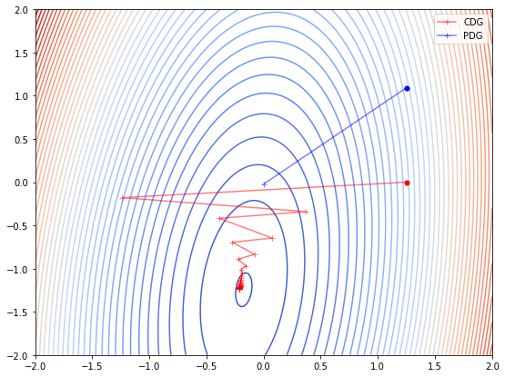